# Assignment 7 example answer key

Phil Hurvitz | e-mail | [www](http://gis.washington.edu/phurvitz)

2021-03-01 01:26

```r
# key setups
library(knitr) # knitr for kable tables
library(kableExtra) # pretty tables
library(ggplot2)
library(tidyverse)
library(pdftools)
library(labelled)
library(magrittr)

# captions
library(captioner)
table_nums <- captioner(prefix = "Table")
figure_nums <- captioner(prefix = "Figure")

# for having DIV tags
knitr::knit_hooks$set(class = function(before, options, envir) {
    if(before){
        sprintf("<div class = '%s'>", options$class)
    }else{
        "</div>"
    }
})

knitr::opts_chunk$set(warning = FALSE, message = FALSE)
```

This document presents some possible answers for Assignment 7.

## 1.

**Generate a new data frame from the full public Add Health data set (http://staff.washington.edu/phurvitz/csde502_winter_2021/data/21600-0001-Data.dta.zip) that consists of a subset of at least four of the original columns. Do not use any of the variables used as examples in Lesson 7.**

```r
myUrl <- "http://staff.washington.edu/phurvitz/csde502_winter_2021/data/21600-0001-Data.dta.zip"
# zipfile in $temp
zipfile <- file.path(Sys.getenv("TEMP"), basename(myUrl))
# dta file in $temp
dtafile <- tools::file_path_sans_ext(zipfile)
# check if the dta file exists
if(!file.exists(dtafile)){
    # if the dta file doesn't exist, check for the zip file
    # check if the zip file exists, download if necessary
    if(!file.exists(zipfile)){
        curl::curl_download(url = myUrl, destfile = zipfile)
    }
    # unzip the downloaded zip file
    unzip(zipfile = zipfile, exdir = Sys.getenv("TEMP"))
}

# if the data set has not been read, read it in
if(!exists("ahcomplete")){
    ahcomplete <- haven::read_dta(dtafile)
}
# lowercase column names
colnames(ahcomplete) %<>% str_to_lower()

# create a subset of columns
dat <- ahcomplete %>%
    select(aid,
           s2,
           s10a,
           s46c,
           s47,
           s62m)
# new column names
newcolnames <- c("aid", "sex", "mathgrade", "homework", "tvtime", "likemyself")
```

### 1.a

**At least one of the variables should be able to stratify the respondents into meaningful analytic groups.**

All of the variables other than `aid` could be used to stratify. The variables I selected are `aid, s2, s10a, s46c, s47, s62m`, renamed to `aid, sex, mathgrade, homework, tvtime, likemyself`

```r
# set the column names
names(dat) <- newcolnames
```

### 1.b

**The data frame should have a “label” attribute that provides a brief but informative description of the table.**

```r
attributes(dat)$label <- "A subset of Add Health public data.
Selected variables were:
s2, s10a, s46c, s47, and s62m.
The variables were renamed to:
aid, sex, mathgrade, homework, tvtime, and likemyself."
```

The descriptive label is:

```r
# show the labels
cat(attributes(dat)$label)
```

```
A subset of Add Health public data.
Selected variables were:
s2, s10a, s46c, s47, and s62m.
The variables were renamed to:
aid, sex, mathgrade, homework, tvtime, and likemyself.
```

### 1.c

**The columns should be formatted as factor variables with proper value labels and ordering if applicable.**

The following code converts the variables to factors.

```r
# save a previous version for comparison
datorig <- dat

# a function to convert a column with value attribute labels to a factor
f_fct <- function(x){
    factor(x, labels = attributes(x)$labels %>% names(), ordered = TRUE)
}

# mutate all columns other than the first (aid), using the f_fct function
#   to convert the columns to factors
dat %<>%
    mutate_at(.vars = -1,
              .funs = f_fct
    )
```

Here we see the first few records of the data frame before and after converting variables to factors (1, 2, respectively).

```r
# show the first few records
datorig %>%
    head() %>%
    kable(caption = "Raw data") %>%
    kable_styling(full_width = FALSE, position = "left")
```

Table 1: Raw data

| aid | sex | mathgrade | homework | tvtime | likemyself |
| --- | --- | --- | --- | --- | --- |
| 57100270 | 2 | 2 | 0 | 2 | 2 |
| 57101310 | 2 | 3 | 2 | 4 | 2 |
| 57103171 | 1 | 1 | 0 | 1 | 1 |
| 57103869 | NA | NA | NA | NA | NA |
| 57104553 | 2 | 2 | 0 | 2 | 1 |
| 57104649 | 1 | 2 | 0 | 2 | 1 |

```r
# show the first few records
dat %>%
    head() %>%
    kable(align = rep("r", ncol(dat)), caption = "Data converted to factors") %>%
    kable_styling(full_width = FALSE, position = "left")
```

Table 2: Data converted to factors

aid

sex

mathgrade

homework

tvtime

likemyself

57100270

2. Female
2. B
0. Never
2. 1-2 hours
2. Agree

57101310

2. Female
3. C
2. About once a week
4. More than 4 hours
2. Agree

57103171

1. Male
1. A
0. Never
1. Less than 1 hour
1. Strongly agree

57103869

NA

NA

NA

NA

NA

57104553

2. Female
2. B
0. Never
2. 1-2 hours
1. Strongly agree

57104649

1. Male
2. B
0. Never
2. 1-2 hours
1. Strongly agree

### 1.d

**The columns should have informative attributes as you see fit.**

I have used the labels from the original data set to label the new variables, which are listed below.

```r
# column label
labs <- datorig %>%
    map(~ attributes(.)$label) %>%
    unlist()

# run a loop to label the columns
for(i in 1:ncol(dat)){
    # get the label
    mylab <- labs[i]
    # get the column name
    cname <- names(dat)[i]
    # formulate a command
    mycmd <- sprintf("attributes(dat$%s)$label <- '%s'", cname, mylab)
    # run the command
    eval(parse(text = mycmd))
}

# print the labels
dat %>%
    map(~ attributes(.)$label)
```

[output not shown]

## 2

**The code should save the data frame as an RDS file in the $TEMP location, which can be specified in R as Sys.getenv("TEMP").**

The following code saves the data set as an RDS file (`file.path(tmpdir, "phurvitz_assn8.Rmd")`).

```r
# save the data set
tmpdir <- Sys.getenv("TEMP")
saveRDS(object = dat, file = file.path(tmpdir, "phurvitz_assn8.Rmd"))
```

## 3

**Create some frequency tables:**

### 3.a

**Create a frequency table from each variable, using both counts and percentages.**

The following code runs a loop over each column other than `aid` to create and print a tabulation.

```r
# create a tabulation for each column other than aid
for(i in 2:ncol(dat)){
    # column name
    cname <- names(dat)[i]

    # tabulate
    ftab <- dat %>%
        group_by(dat[,i]) %>%
        summarise(n = n()) %>%
        mutate(`%` = (n / sum(n) * 100) %>% round(1)) %>%
        kable() %>%
        kable_styling(full_width = FALSE,
                      position = "left") %>%
        print()
}
```

sex

n

%

1. Male

2235

34.4

2. Female

2483

38.2

9. Multiple response

1

0.0

NA

1785

27.4

mathgrade

n

%

1. A

1156

17.8

2. B

1503

23.1

3. C

899

13.8

4. D or lower

376

5.8

5. I didn't take this subject

63

1.0

7. Legitimate skip

314

4.8

8. I don't know

262

4.0

9. Multiple response

3

0.0

NA

1928

29.6

homework

n

%

0. Never

965

14.8

1. Just a few times

1327

20.4

2. About once a week

629

9.7

3. Almost everyday

928

14.3

4. Everyday

667

10.3

9. Multiple response

3

0.0

NA

1985

30.5

tvtime

n

%

0. None

191

2.9

1. Less than 1 hour

849

13.1

2. 1-2 hours

1596

24.5

3. 3-4 hours

1101

16.9

4. More than 4 hours

821

12.6

9. Multiple response

2

0.0

NA

1944

29.9

likemyself

n

%

1. Strongly agree

1446

22.2

2. Agree

1436

22.1

3. Neither agree nor disagree

773

11.9

4. Disagree

439

6.7

5. Strongly disagree

168

2.6

9. Multiple response

10

0.2

NA

2232

34.3

### 3.b

**Create a frequency table based on at least two variables, also with counts and percentages.**

The following tables present tabulations of grades in math by time spent watching TV. Table 3 presents percentage sums by grade, and 4 presents percentage sums by TV time.

```r
dat %>%
    filter(mathgrade <= "(4) D or lower" &
               tvtime < "(9) Multiple response") %>%
    group_by(mathgrade, tvtime) %>%
    summarise(n = n()) %>%
    mutate(pct = (n / sum(n) * 100) %>% round(1),
           `n (%)` = str_c(n, " (", pct, ")", sep = "")) %>%
    select(mathgrade, tvtime, `n (%)`) %>%
    spread(mathgrade, `n (%)`) %>%
    kable(caption = "Tabulation of grades in math and TV time, percent total by grade") %>%
    kable_styling(full_width = FALSE,
                  position = "left") %>%
    add_header_above(header = c(" " = 1, "math grade, n (%)" = 4))
```

Table 3: Tabulation of grades in math and TV time, percent total by grade

math grade, n (%)

tvtime

1. A
2. B
3. C
4. D or lower
0. None

57 (5)

72 (4.9)

27 (3.1)

9 (2.5)

1. Less than 1 hour

251 (22.1)

265 (18.1)

153 (17.7)

55 (15.4)

2. 1-2 hours

438 (38.6)

525 (35.8)

296 (34.3)

119 (33.3)

3. 3-4 hours

261 (23)

356 (24.3)

209 (24.2)

88 (24.6)

4. More than 4 hours

128 (11.3)

248 (16.9)

177 (20.5)

86 (24.1)

```r
dat %>%
    filter(mathgrade <= "(4) D or lower" &
               tvtime < "(9) Multiple response") %>%
    group_by(tvtime, mathgrade) %>%
    summarise(n = n()) %>%
    mutate(pct = (n / sum(n) * 100) %>% round(1),
           `n (%)` = str_c(n, " (", pct, ")", sep = "")) %>%
    select(mathgrade, tvtime, `n (%)`) %>%
    spread(mathgrade, `n (%)`) %>%
    kable(caption = "Tabulation of grades in math and TV time, percent total by TV time") %>%
    kable_styling(full_width = FALSE,
                  position = "left") %>%
    add_header_above(header = c(" " = 1, "math grade, n (%)" = 4))
```

Table 4: Tabulation of grades in math and TV time, percent total by TV time

math grade, n (%)

tvtime

1. A
2. B
3. C
4. D or lower
0. None

57 (34.5)

72 (43.6)

27 (16.4)

9 (5.5)

1. Less than 1 hour

251 (34.7)

265 (36.6)

153 (21.1)

55 (7.6)

2. 1-2 hours

438 (31.8)

525 (38.1)

296 (21.5)

119 (8.6)

3. 3-4 hours

261 (28.6)

356 (38.9)

209 (22.9)

88 (9.6)

4. More than 4 hours

128 (20)

248 (38.8)

177 (27.7)

86 (13.5)

## 4

**Create at least one graph from data in the data frame.**

Figure 1 shows the count of subjects by math grades and frequency of having trouble getting homework done. For those who never had a problem getting homework done, grade A was most prevalent. But for all other groups, grade B was most prevalent. The most prevalent group had trouble completing their homework "just a few times a week."

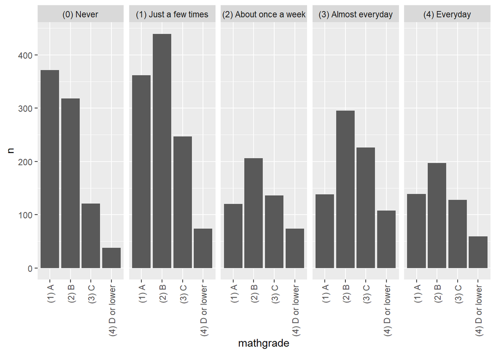

Figure 1: Math grades by frequency of trouble getting homework done

```r
dsum <- dat %>%
    filter(mathgrade <= "(4) D or lower" &
               homework < "(9) Multiple response") %>%
    group_by(homework, mathgrade) %>%
    summarise(n = n())

ggplot(data = dsum, mapping = aes(x = mathgrade, y = n)) +
    geom_bar(stat = "identity") +
    facet_grid(~ homework) +
    theme(axis.text.x = element_text(angle = 90, vjust = 0.5, hjust = 1))
```

## Source code

csde502_2021_assignment07_answers.Rmd

```r
cat(readLines(con = "csde502_2021_assignment07_answers.Rmd"), sep = '\n')
```

````
---
title: "Assignment 7 example answer key"
author: "Phil Hurvitz | [e-mail](mailto:phurvitz@uw.edu) | [www](http://gis.washington.edu/phurvitz)"
date: '`r format(Sys.time(), "%Y-%m-%d %H:%M")`'
header-includes: #allows you to add in your own Latex packages
- \usepackage{float} #use the 'float' package
- \floatplacement{figure}{H} #make every figure with caption = h
output:
    bookdown::html_document2:
        number_sections: true
        self_contained: true
        code_folding: hide
        toc: true
        toc_float:
            collapsed: true
            smooth_scroll: false
urlcolor: blue
---

<!--these following settings control width and also make a DIV tag for black outlines for figures-->
<style type="text/css">
.main-container {
  max-width: 2400px !important;
  margin-left: auto;
  margin-right: auto;
}
</style>

<style>
.outline {
   background-color: #000000;
   padding:1px;
   display: inline-block;
}
</style>

```{r setup, message=FALSE, warning=FALSE}
# key setups
library(knitr) # knitr for kable tables
library(kableExtra) # pretty tables
````

[output cut: 271 more lines]

````
ggplot(data = dsum, mapping = aes(x = mathgrade, y = n)) +
    geom_bar(stat = "identity") +
    facet_grid(~ homework) +
    theme(axis.text.x = element_text(angle = 90, vjust = 0.5, hjust = 1))

```



<h2>Source code</h2>
[csde502_2021_assignment07_answers.Rmd](csde502_2021_assignment07_answers.Rmd)

```{r comment=''}
cat(readLines(con = "csde502_2021_assignment07_answers.Rmd"), sep = '\n')
```
````